# Assessment

### Project :1 Linear Regression model: Used Cars Sales Prediction

There is an automobile company XYZ from USA which aspires to enter the US used car market by setting up their company locally to give competition to their counterparts. They want to understand the factors affecting the pricing of cars in the market, since those may be vastly different from the new car market.

The market for used cars has witnessed a significant surge in demand in recent times, surpassing that of new cars. Consequently, pricing strategies for used vehicles have become crucial for businesses to remain competitive in the market. The value of a used car is influenced by a multitude of factors, such as mileage, model, and year of production. It is imperative for industry players to consider these variables while determining the actual worth of a used car.

First step document that lists the output of your exploratory analysis, any issues, or problems you may see with data that need follow-up, and some basic descriptive analysis that you think highlights important outcomes/findings from the data. Based on your findings, the next level of analysis will be charted out. Build a multiple linear regression model for predicting the price of a used car and provide meaningful inferences.

**Dataset: Used_cars_sales.xlsx**

**Data Dictionary**

```
Name 	                 Name of the Car on Sell
City 	                 City of the Car on Sell
Years             	     Year of manufacture
Km_driven  	             Kms Car travelled
Fuel_Type  	             Petrol, Diesel, CNG
Transmission  	         Manual, Automatic
Owner_Type     	         First, Second, Third
Mileage  	             Mileage of the Car
Engine 	                 Engine Displacement
Power             	     Power of Engine
Seats              	     No. of Seats in Car
Selling_price   	     Selling price of a Car (Target)
```

**Initial Guidelines:**

1. Ensure to follow to Use Id’s provided by UNext for naming file as conventions.
2. Create GitHub account and submit the GitHub link.

### Software Engineering aspect:

Utilize software engineering aspects while building Machine learning model using modular programming principles to organize your code into reusable functions or classes to enhance readability, maintainability, and collaboration.

### General Instructions

- The cells in the Jupyter notebook can be executed any number of times for testing the solution
- Refrain from modifying the boilerplate code as it may lead to unexpected behavior
- The solution is to be written between the comments `# code starts here` and `# code ends here`
- On completing all the questions, the assessment is to be submitted on moodle for evaluation
- Before submitting the assessment, there should be `no error` while executing the notebook. If there are any error causing code, please comment it.
- The kernel of the Jupyter notebook is to be set as `Python 3 (ipykernel)` if not set already
- Include imports as necessary
- For each of the task, `Note` section will provide you hints to solve the problem.
- Do not use `PRINT` statement inside the `Except` Block. Please use `return` statement only within the except block

#### **Utilize software engineering aspects while building Machine learning model using modular programming principles to organize your code into reusable functions or classes to enhance readability, maintainability, and collaboration.**

### Loading required libraries and packages

#### NOTE:

Import various libraries and modules used in data analysis, machine learning, and visualization tasks in Python such as `pandas`, `numpy`, `sklearn`, `matplotlib`, `seaborn`, `statsmodels`, `statsmodels.api`, `sklearn.model_selection`, `sklearn.linear_model`, `sklearn.metrics`, `sklearn.preprocessing`. There are 2 ways to import the libraries and modules:

- import numpy as np
- from sklearn.model_selection import train_test_split

```python
# Required imports
import numpy as np
import pandas as pd
import matplotlib.pyplot as plt
import seaborn as sns
from sklearn.model_selection import train_test_split
```

### Task 1: Load the 'car_sales-dataset' available in the Dataset folder within the Project folder on the desktop. Perform preliminary EDA with key observations and insights- (weightage - 20 marks)

#### T1.1: Load the Used_cars_sales dataset using try and except blocks. (weightage - 2 marks) (AE)

#### NOTE:

- The `read_excel` method in Pandas allows you to read Excel files and convert them into a DataFrame, which is a two-dimensional tabular data structure in Pandas.
- Do not use `PRINT` statement inside the `Except` Block. Please use `return` statement only within the except block

```python
def load_the_dataset(dataset_location : str)->pd.DataFrame:
    car_sales = None
    # code starts here
    car_sales = pd.read_excel("Used_cars_sales.xlsx")
    # code ends here
    return car_sales
```

```python
# store the result of the dataset
dataset_location = 'Used_cars_sales.xlsx'
car_sales=load_the_dataset(dataset_location)
car_sales
```

|  | Sales_ID | name | year | selling_price | km_driven | fuel | seller_type | transmission | owner | mileage | engine | max_power | seats | City | Postal_code | Sales_status |
| --- | --- | --- | --- | --- | --- | --- | --- | --- | --- | --- | --- | --- | --- | --- | --- | --- |
| 0 | 1 | Maruti Swift Dzire VDI | 2014 | 450000 | 145500 | Diesel | Individual | Manual | First Owner | 23.4 kmpl | 1248 CC | 74 bhp | 5 | Mumbai | 400001 | Y |
| 1 | 2 | Skoda Rapid 1.5 TDI Ambition | 2014 | 370000 | 120000 | Diesel | Individual | Manual | Second Owner | 21.14 kmpl | 1498 CC | 103.52 bhp | 5 | Ranchi | 834008 | Y |
| 2 | 3 | Honda City 2017-2020 EXi | 2006 | 158000 | 140000 | Petrol | Individual | Manual | Third Owner | 17.7 kmpl | 1497 CC | 78 bhp | 5 | Noida | 201301 | Y |
| 3 | 4 | Hyundai i20 Sportz Diesel | 2010 | 225000 | 127000 | Diesel | Individual | Manual | First Owner | 23.0 kmpl | 1396 CC | 90 bhp | 5 | Dehradun | 248141 | Y |
| 4 | 5 | Maruti Swift VXI BSIII | 2007 | 130000 | 120000 | Petrol | Individual | Manual | First Owner | 16.1 kmpl | 1298 CC | 88.2 bhp | 5 | Chennai | 600020 | Y |
| ... | ... | ... | ... | ... | ... | ... | ... | ... | ... | ... | ... | ... | ... | ... | ... | ... |
| 7901 | 8124 | Hyundai i20 Magna | 2013 | 320000 | 110000 | Petrol | Individual | Manual | First Owner | 18.5 kmpl | 1197 CC | 82.85 bhp | 5 | Indore | 453551 | N |
| 7902 | 8125 | Hyundai Verna CRDi SX | 2007 | 135000 | 119000 | Diesel | Individual | Manual | Third Owner | 16.8 kmpl | 1493 CC | 110 bhp | 5 | Dehradun | 248141 | N |
| 7903 | 8126 | Maruti Swift Dzire ZDi | 2009 | 382000 | 120000 | Diesel | Individual | Manual | First Owner | 19.3 kmpl | 1248 CC | 73.9 bhp | 5 | Kolkata | 700027 | N |
| 7904 | 8127 | Tata Indigo CR4 | 2013 | 290000 | 25000 | Diesel | Individual | Manual | First Owner | 23.57 kmpl | 1396 CC | 70 bhp | 5 | Vellore | 632001 | N |
| 7905 | 8128 | Tata Indigo CR4 | 2013 | 290000 | 25000 | Diesel | Individual | Manual | First Owner | 23.57 kmpl | 1396 CC | 70 bhp | 5 | Dehradun | 248141 | N |

7906 rows × 16 columns

#### NOTE:

To count each unique value in the 'name' column of the DataFrame car_sales we can use the value_counts() method. It returns a Series where the index contains unique car names, and the values represent the frequency of each name in the DataFrame. To find the name of the car brand with the maximum count we can use the idxmax() method on the series. It returns the name of the most selling brand in the DataFrame.

```python
def get_name_value_counts(car_sales):
    most_selling_brand = None
    #code starts here
    most_selling_brand = car_sales["name"].value_counts()
    most_selling_brand = most_selling_brand.idxmax()
    #code ends here
    return most_selling_brand
```

```python
get_name_value_counts(car_sales)
```

```
'Maruti Swift Dzire VDI'
```

#### T1.3: Name the top 5 cities which has highest sales. (weightage - 2 marks) (AE)

**Hint: Output should be city name only in the format of list**

#### NOTE:

To calculate the count of each unique value in the 'City' column of the DataFrame data use the value_counts() method. It will returns a Series where the index contains unique city names, and the values represent the frequency of each city in the DataFrame. Now to select the top 5 cities with the highest sales count use the head() method on the Series. By default, head() returns the first 5 rows of the Series, which in this case, correspond to the cities with the highest sales.

```python
def get_city_value_counts(data):
    city_with_max_sales = None
    #code starts here
    city_with_max_sales = data["City"].value_counts()
    #code ends here
    return city_with_max_sales.head()
```

```python
# Remove 'name', 'count', and 'dtype' information
city_name=get_city_value_counts(car_sales)
list(city_name.index)
```

```
['Delhi', 'Noida', 'Mumbai', 'Coimbatore', 'Vellore']
```

#### T1.4: Check missing values in the data in terms of percentage using error handling technique and do missing value treatment. (weightage - 2 marks) (AE)

#### NOTE:

- Find the percentage of missing values in the data by dividing the total number of missing values by the total number of rows and multiplying by 100, you - will get the percentage of missing values for each column.

Use `isnull().sum()` to calculate the total number of missing values in each column and `shape[0]` to get the total number of rows in the DataFrame.

- Do not use `PRINT` statement inside the `Except` Block. Please use `return` statement only within the except block

```python
def missing_value_check(data):
    missing_percentage = None
    #code starts here
    missing_percentage = 100*(data.isnull().sum()/data.shape[0])

    #code ends here
    return missing_percentage
```

```python
missing_value_check(car_sales)
```

```
Sales_ID         0.000000
name             0.000000
year             0.000000
selling_price    0.000000
km_driven        0.000000
fuel             0.240324
seller_type      0.202378
transmission     0.000000
owner            0.000000
mileage          0.000000
engine           0.000000
max_power        0.000000
seats            0.000000
City             0.000000
Postal_code      0.000000
Sales_status     0.000000
dtype: float64
```

#### NOTE:

For treating the missing value first define the list of columns containing the names of the columns with missing values which will be treated. Iterating over each column name in the columns list fill the missing values in the dataset for that column with the mode value of that column.

```python
# Missing value treatment
def missing_value_treatment(car_sales):
    # Example: Replace missing values with mode value
    columns = ['fuel','seller_type']
    for column in columns:
        mode_value = car_sales[column].mode()[0]
        car_sales[column].fillna(mode_value,inplace=True)
#     car_sales = car_sales.fillna(car_sales.mode(axis=0))

    return car_sales
```

```python
car_sales = missing_value_treatment(car_sales)
print(car_sales.isnull().sum())
```

```
Sales_ID         0
name             0
year             0
selling_price    0
km_driven        0
fuel             0
seller_type      0
transmission     0
owner            0
mileage          0
engine           0
max_power        0
seats            0
City             0
Postal_code      0
Sales_status     0
dtype: int64
```

#### T1.5: Detect Outliers in the data and do outlier treatment. Plot a boxplot to visualize outliers in the data. (weightage – 2 marks) (ME)

- The extreme values in selling_price due to genuine market conditions, such as luxury properties.Keep the values as it is.

#### NOTE:

The `sns.boxplot()` function in Seaborn is used to create a box plot visualization, which is a convenient way to visually summarize the distribution of numerical data and identify outliers. Using this detect the outliers in the `car_sales` dataframe.

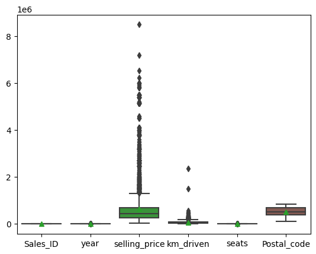

```python
# plot a boxplot to visualize outliers in the data
sns.boxplot(showmeans=True,data=car_sales)
```

#### Define a function `treat_outliers_iqr` to treat outliers using IQR method. Use `median` as treatment method.

#### NOTE:

The outliers in the dataset can be treated using the Interquartile Range (IQR) method. It replaces the outliers with either the median or the mean, based on the specified treatment method. Calculate the first quartile (Q1), third quartile (Q3), and Interquartile Range (IQR) of the data along with the lower and upper bounds for outliers. Then replace the outliers with the median of the data.

```python
# Define a function to detect and treat outliers using IQR method
def treat_outliers_iqr(data,treatment='median'):
    #code starts here
    Q1= data.quantile(0.25)
    Q3 = data.quantile(0.75)
    IQR = Q3-Q1
    lower_bound = Q1 - (1.5*IQR)
    upper_bound = Q3 + (1.5*IQR)
    outlier = (data < lower_bound) | (data > upper_bound)
    data.loc[outlier] = data.median()

    #code ends here
    return data
```

```python
# Detect outliers and treat them with median value
numeric_columns=['km_driven']
```

```python
# Display the treated DataFrame
for column in numeric_columns:
    car_sales[column] = treat_outliers_iqr(car_sales[column], treatment='median')

# Display the treated DataFrame
print(car_sales.head())
```

```
   Sales_ID                          name  year  selling_price  km_driven  \
0         1        Maruti Swift Dzire VDI  2014         450000     145500
1         2  Skoda Rapid 1.5 TDI Ambition  2014         370000     120000
2         3      Honda City 2017-2020 EXi  2006         158000     140000
3         4     Hyundai i20 Sportz Diesel  2010         225000     127000
4         5        Maruti Swift VXI BSIII  2007         130000     120000

     fuel seller_type transmission         owner     mileage   engine  \
0  Diesel  Individual       Manual   First Owner   23.4 kmpl  1248 CC
1  Diesel  Individual       Manual  Second Owner  21.14 kmpl  1498 CC
2  Petrol  Individual       Manual   Third Owner   17.7 kmpl  1497 CC
3  Diesel  Individual       Manual   First Owner   23.0 kmpl  1396 CC
4  Petrol  Individual       Manual   First Owner   16.1 kmpl  1298 CC

    max_power  seats      City  Postal_code Sales_status
0      74 bhp      5    Mumbai       400001            Y
1  103.52 bhp      5    Ranchi       834008            Y
2      78 bhp      5     Noida       201301            Y
3      90 bhp      5  Dehradun       248141            Y
4    88.2 bhp      5   Chennai       600020            Y
```

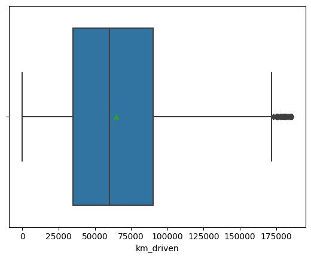

```python
### Visualization -boxplot
sns.boxplot(x= 'km_driven',showmeans=True,data=car_sales)
```

#### T1.6: Which variables are significant in predicting the price of a used car? To answer this question, it is important to understand the correlation between the different variables. i.e how much the other features effect the selling price of a used car. (Bivariate analysis) (weightage - 3 marks) (AE)

#### NOTE:

To understand the correlation between different variables , we have to convert the non numeric columns into numeric columns. Clean the data type of the 'max_power', 'engine', and 'mileage' columns in a DataFrame by converting them into numeric types by removing the units in order to perform correlation on them.

Removes the following non-numeric suffix using string manipulation functions:

- 'bhp' for max_power,
- 'CC' for engine,
- 'kmpl' or 'km/kg' for mileage

Converts the data type of each of the above column to float

```python
# define a function to convert data type of Max power, Engine and Mileage into numeric
def clean_car_sales_data(df):
    #code starts here
    unit_removal = {
        "max_power":"bhp",
        "engine":"CC",
        "mileage":r"kmpl|km\/kg"
#         "max_power" : lambda x: x.replace("bhp",""),
#         "engine" : lambda x: x.replace("CC",""),
#         "mileage" : lambda x: x.replace("kmpl",""),
#         "mileage" : lambda x: x.replace("km/kg","")

    }

    for col,pattern in unit_removal.items():
        df[col] = df[col].astype(str)
        df[col] = df[col].str.replace(pattern,"",regex=True).astype(float)
        df[col] = pd.to_numeric(df[col])

    #code ends here
    return df
```

```python
car_sales = clean_car_sales_data(car_sales)
print(car_sales)
```

```
      Sales_ID                          name  year  selling_price  km_driven  \
0            1        Maruti Swift Dzire VDI  2014         450000     145500
1            2  Skoda Rapid 1.5 TDI Ambition  2014         370000     120000
2            3      Honda City 2017-2020 EXi  2006         158000     140000
3            4     Hyundai i20 Sportz Diesel  2010         225000     127000
4            5        Maruti Swift VXI BSIII  2007         130000     120000
...        ...                           ...   ...            ...        ...
7901      8124             Hyundai i20 Magna  2013         320000     110000
7902      8125         Hyundai Verna CRDi SX  2007         135000     119000
7903      8126        Maruti Swift Dzire ZDi  2009         382000     120000
7904      8127               Tata Indigo CR4  2013         290000      25000
7905      8128               Tata Indigo CR4  2013         290000      25000

        fuel seller_type transmission         owner  mileage  engine  \
0     Diesel  Individual       Manual   First Owner    23.40  1248.0
```

[output cut: 25 more lines]

#### Correlation between numerical variables and target variable

#### NOTE:

Using Python function `corr` compute the correlation matrix of a DataFrame df containing numeric columns. Ensure that only numeric columns are included in the correlation computation.

```python
def corr(df):
    correlation = None
    #code starts here
    correlation = df.select_dtypes(include=[np.number]).corr()
    #code ends here
    return correlation
```

```python
corr_data = corr(car_sales)
corr_data
```

|  | Sales_ID | year | selling_price | km_driven | mileage | engine | max_power | seats | Postal_code |
| --- | --- | --- | --- | --- | --- | --- | --- | --- | --- |
| Sales_ID | 1.000000 | -0.001304 | -0.011767 | -0.000809 | 0.028627 | -0.011279 | -0.003717 | -0.014154 | -0.010781 |
| year | -0.001304 | 1.000000 | 0.413139 | -0.502279 | 0.328544 | 0.018263 | 0.226598 | -0.007923 | 0.004923 |
| selling_price | -0.011767 | 0.413139 | 1.000000 | -0.291603 | -0.127900 | 0.456573 | 0.749512 | 0.042065 | 0.008702 |
| km_driven | -0.000809 | -0.502279 | -0.291603 | 1.000000 | -0.147062 | 0.184414 | -0.065224 | 0.205862 | -0.008811 |
| mileage | 0.028627 | 0.328544 | -0.127900 | -0.147062 | 1.000000 | -0.576408 | -0.374621 | -0.451700 | -0.009599 |
| engine | -0.011279 | 0.018263 | 0.456573 | 0.184414 | -0.576408 | 1.000000 | 0.703975 | 0.611103 | 0.004543 |
| max_power | -0.003717 | 0.226598 | 0.749512 | -0.065224 | -0.374621 | 0.703975 | 1.000000 | 0.191999 | 0.007089 |
| seats | -0.014154 | -0.007923 | 0.042065 | 0.205862 | -0.451700 | 0.611103 | 0.191999 | 1.000000 | -0.004773 |
| Postal_code | -0.010781 | 0.004923 | 0.008702 | -0.008811 | -0.009599 | 0.004543 | 0.007089 | -0.004773 | 1.000000 |

#### T1.7: Come up with Insights and validate the hypothesis: (weightage: 3 marks) (AE)

(i) Is there a statistically significant difference in the average mileage of cars across different fuel types and transmission types?

(ii) Is there a statistically significant difference in the selling prices of cars between individual and dealer sellers?

(iii)Is there a relationship between the type of fuel and transmission in cars?

#### (i) Is there a statistically significant difference in the average mileage of cars across different fuel types and transmission types?

- If yes, set `result1` as "There is a significant difference in the average mileage of cars across different fuel types and transmission types"
- If no, set `result1` as "There is no significant difference in the average mileage of cars across different fuel types and transmission types"

#### NOTE:

Conduct an Analysis of Variance (ANOVA) test to determine if there is a significant difference in the average mileage of cars across different fuel types and transmission types.

- Groups the data to create separate groups for each category.
- Then perform the ANOVA test using the stats.f_oneway() function from the scipy.stats module.
- Compare the obtained p-value with a significance level (alpha)
- Based on the comparison, determine whether there is a significant difference in the average mileage of cars across different fuel types and transmission types.

```python
import scipy.stats as stats
from scipy.stats import f_oneway
def perform_anova(car_data):
    result1 = None
    # Code starts here

    grouped_data = car_data.groupby(['fuel','transmission'])['mileage']
    mileage_by_group = []
    for name,group in grouped_data:
        mileage_by_group.append(group.to_numpy())
#     samples = [group.values for _, group in grouped_data]
#     samples = np.concatenate(grouped_data,axis=0)
    # Perform ANOVA
    F,p = f_oneway(*mileage_by_group)
    alpha = 0.05
    # Compare p-value with significance level (e.g., 0.05)
    if p < alpha:
        result1 = "There is a significant difference in the average mileage of cars across different fuel types and transmission types"
    else:
        result1 = "There is no significant difference in the average mileage of cars across different fuel types and transmission types"
    # Code ends here

    # Return ANOVA results
    return result1
```

```python
# Call the function
perform_anova(car_sales)
```

```
'There is a significant difference in the average mileage of cars across different fuel types and transmission types'
```

#### (ii) Is there a statistically significant difference in the selling prices of cars between individual and dealer sellers?

- If yes,set `result2` as "There is a statistically significant difference in the selling prices of cars between individual and dealer sellers"
- If no, set `result2` as "There is no statistically significant difference in the selling prices of cars between individual and dealer sellers"

#### Note:

Conducts an independent two-sample t-test to determine if there is a statistically significant difference in the selling prices of cars between individual and dealer sellers.

- Filter the data based on the 'seller_type' column to separate the selling prices of cars sold by individual sellers and dealer sellers.
- Perform the independent two-sample t-test using the ttest_ind() function from the scipy.stats module.
- Compare the obtained p-value with a significance level (alpha)
- Based on the comparison,determines whether there is a statistically significant difference in the selling prices of cars between individual and dealer sellers.

```python
from scipy.stats import ttest_ind
def seller_type_influence_test(car_sales):
    result2 = None
    # Code starts here

    # Filter data based on seller type
    individual_sales = car_sales[car_sales['seller_type']== 'Individual']['selling_price']
    dealer_sales = car_sales[car_sales['seller_type']== 'Dealer']['selling_price']
    # Perform independent t-test
    statistic, pvalue = ttest_ind(individual_sales,dealer_sales)

    # Set significance level
    alpha = 0.05

    # Interpret the results
    if pvalue < alpha:
        result2 = "There is a statistically significant difference in the selling prices of cars between individual and dealer sellers"
    else:
        result2 = "There is no statistically significant difference in the selling prices of cars between individual and dealer sellers"

    # Code ends here
    return result2
```

```python
seller_type_influence_test(car_sales)
```

```
'There is a statistically significant difference in the selling prices of cars between individual and dealer sellers'
```

#### (iii) Is there a relationship between the type of fuel and transmission in cars?

- If yes,set `result3` as "There is a statistically significant relationship between the type of fuel and transmission in cars"
- If no, set `result3` as "There is no statistically significant relationship between the type of fuel and transmission in cars"

#### NOTE:

Conduct a chi-square test of independence to determine if there is a statistically significant relationship between the type of fuel and transmission in cars.

- Creates a contingency table of observed frequencies using the pd.crosstab() function.
- Perform the chi-square test of independence using the stats.chi2_contingency() function from the scipy.stats module.
- Compare the obtained p-value with a significance level (alpha)
- Based on the comparison, determine whether there is a statistically significant relationship between the type of fuel and transmission in cars.

```python
from scipy.stats import chi2_contingency
def chi_square_test(car_data):
    result3 = None
    # Create a contingency table of observed frequencies
    observed_table = pd.crosstab(car_data['fuel'],car_data['transmission'])

    # Perform Chi-square test
    chi2, pval, degrees_of_freedom, expected_table = chi2_contingency(observed_table)

    # Compare p-value with significance level (e.g., 0.05)
    alpha = 0.05

    if pval<= alpha:
        result3 = "There is a statistically significant relationship between the type of fuel and transmission in cars"
    else:
        result3 = "There is no statistically significant relationship between the type of fuel and transmission in cars"
    # Return Chi-square statistic, p-value, and result
    return result3
```

```python
# Call the function
chi_square_test(car_sales)
```

```
'There is a statistically significant relationship between the type of fuel and transmission in cars'
```

#### T1.8: Data Transformation: remove the given variables for model building process ("name","Postal_code","Sales_ID"). Apply normalization technique (standard scaler). (weightage - 2 marks) (AE)

#### NOTE:

Drop the varaiables "name","Postal_code","Sales_ID" from the dataframe using the drop() function.

```python
# drop the given variables
from sklearn.preprocessing import StandardScaler
def drop_var1(data):
    # Code starts here
    data = data.drop(columns=["name","Postal_code","Sales_ID"])
    data = data.dropna()

    numerical_features = ["year","km_driven","mileage","engine","max_power","seats"]
    scaler = StandardScaler()
    data[numerical_features] = scaler.fit_transform(data[numerical_features])
    # Code ends here
    return data
```

```python
car_sales = drop_var1(car_sales)
```

#### T1.9: Handling categorical features: Apply encoding technique to convert categorical variable into numerical. Use try and except blocks. (weightage - 2 marks) (AE)

#### NOTE:

scikit-learn expects all features to be numeric. So how do we include a categorical feature in our model? Transform city variable to 4 categories such as `North_city, South_city, East_city and West_city` according to the below given list.

```python
# Define regions
def city_region(sales_data):
    city_regions = {
    'north_cities' : ['Dehradun','Mumbai','Jaipur','Indore','Pune','Aurangabad', 'Delhi','Ludhiana', 'kanpur', 'Gangtok', 'Noida'],
    'south_cities' : ['Chennai','Mysore', 'Bangalore', 'Nellore', 'Coimbatore','Mangalore','Hyderabad','Vellore','Thrissur'],
    'east_cities' : ['Ranchi', 'Kolkata', 'Jamshedpur', 'Patna', 'Bhubaneshwar'],
    'west_cities' : ['Ahmedabad','Kochi','Vadodara', 'Surat']
    }
    # Transform the City variable to 4 categories
    sales_data['City_region'] = sales_data['City'].apply(lambda x: next((region for region, cities in city_regions.items() if x in cities),None))

    # Print the updated DataFrame
    return sales_data
```

```python
#apply city_region() in the original data
car_sales=city_region(car_sales)
car_sales
```

|  | year | selling_price | km_driven | fuel | seller_type | transmission | owner | mileage | engine | max_power | seats | City | Sales_status | City_region |
| --- | --- | --- | --- | --- | --- | --- | --- | --- | --- | --- | --- | --- | --- | --- |
| 0 | 0.004158 | 450000 | 2.090051 | Diesel | Individual | Manual | First Owner | 0.986157 | -0.418188 | -0.492024 | -0.434128 | Mumbai | Y | north_cities |
| 1 | 0.004158 | 370000 | 1.432723 | Diesel | Individual | Manual | Second Owner | 0.426198 | 0.077980 | 0.333827 | -0.434128 | Ranchi | Y | east_cities |
| 2 | -2.066530 | 158000 | 1.948274 | Petrol | Individual | Manual | Third Owner | -0.426129 | 0.075995 | -0.380120 | -0.434128 | Noida | Y | north_cities |
| 3 | -1.031186 | 225000 | 1.613166 | Diesel | Individual | Manual | First Owner | 0.887050 | -0.124457 | -0.044408 | -0.434128 | Dehradun | Y | north_cities |
| 4 | -1.807694 | 130000 | 1.432723 | Petrol | Individual | Manual | First Owner | -0.822561 | -0.318955 | -0.094765 | -0.434128 | Chennai | Y | south_cities |
| ... | ... | ... | ... | ... | ... | ... | ... | ... | ... | ... | ... | ... | ... | ... |
| 7901 | -0.254678 | 320000 | 1.174948 | Petrol | Individual | Manual | First Owner | -0.227914 | -0.519407 | -0.244437 | -0.434128 | Indore | N | north_cities |
| 7902 | -1.807694 | 135000 | 1.406946 | Diesel | Individual | Manual | Third Owner | -0.649122 | 0.068057 | 0.515111 | -0.434128 | Dehradun | N | north_cities |
| 7903 | -1.290022 | 382000 | 1.432723 | Diesel | Individual | Manual | First Owner | -0.029698 | -0.418188 | -0.494822 | -0.434128 | Kolkata | N | east_cities |
| 7904 | -0.254678 | 290000 | -1.016143 | Diesel | Individual | Manual | First Owner | 1.028278 | -0.124457 | -0.603928 | -0.434128 | Vellore | N | south_cities |
| 7905 | -0.254678 | 290000 | -1.016143 | Diesel | Individual | Manual | First Owner | 1.028278 | -0.124457 | -0.603928 | -0.434128 | Dehradun | N | north_cities |

7906 rows × 14 columns

- drop the City variable

```python
def drop_var2(data):
    data.drop(['City'],axis=1, inplace=True)
    return data
```

```python
car_sales = drop_var2(car_sales)
```

#### Encoding technique: convert other categorical variable into factor variable (0,1,2.. categories)

#### NOTE:

Encode categorical columns in a DataFrame using the `LabelEncoder` from scikit-learn.

```python
from sklearn.preprocessing import LabelEncoder
def encode_categorical_columns(df):
    categorical_cols = ["seller_type","transmission","owner","Sales_status","fuel"]
    encoder = LabelEncoder()
    for col in categorical_cols:
        df[col] = encoder.fit_transform(df[col])
    return df
```

```python
# apply it in the original data
car_sales=encode_categorical_columns(car_sales)
```

```python
# convert City_region variable to numeric datatype
categorical_cols = ["City_region"]
encoder = LabelEncoder()
for col in categorical_cols:
    car_sales[col] = encoder.fit_transform(car_sales[col])
```

#### T1.10: Save the cleaned dataset (cleaned_car_sales.xlsx file) by setting the index=False in your GitHub repository for model building process. (This task is for maintaining the version control of datasets) (weightage - 1 mark) (ME)

#### Refer to the Github document from Lumen to create the repository and steps to commit

#### Add your Github repository link below

```python
# https://github.com/Sarthak-Tuteja/usecase1
```

#### NOTE:

Save the DataFrame car_sales to an Excel file named **"cleaned_car_sales.xlsx"** in the `Project` folder on the desktop without including the index column.

```python
# Save the cleaned data set
car_sales.to_excel('cleaned_car_sales.xlsx',index=False)
```

```python
# save it in github repository
```

### Task 2: Build Multiple Linear regression model for predicting the price of a used car. (weightage - 30 marks)

#### T2.1: Load the cleaned dataset and divide it into predictor and target values (X & y) (weightage – 2 marks) (AE)

```python
# load the cleaned data
def load_the_cleaned_dataset(dataset_location):
    cleaned_car_sales = None
    # Code starts here
    cleaned_car_sales = pd.read_excel(dataset_location)
    # Code ends here
    return cleaned_car_sales
```

```python
dataset_location = 'cleaned_car_sales.xlsx'
cleaned_car_sales=load_the_cleaned_dataset(dataset_location)
```

- Separate independent features and target variable

```python
# Separate independent features and target variable
def separate_data_and_target(df):
    X, y = np.ndarray([]),np.ndarray([])
    #code starts here
    X = df.drop("selling_price",axis=1)
    y = df["selling_price"]
    #code ends here
    return X,y
```

```python
# dependent : X, independent : y
X, y = separate_data_and_target(cleaned_car_sales)
```

```python
#print(X.head())
```

```python
#print(y.head())
```

#### T2.2: Split the dataset into train and test in the ratio of 80:20 and apply the scaling technique -RobustScaler. (weightage – 4 marks) (AE)

#### NOTE:

Split the dataset into training and testing. Separate the dependent (data) and independent (target) columns/fields of the dataset and apply the scaling technique -RobustScaler.The requirement is to build a model that performs regression task.

```python
from sklearn.model_selection import train_test_split
from sklearn.preprocessing import RobustScaler

def split_into_train_and_test_normalize_features(X,y):
    X_train, X_test,y_train,y_test = np.ndarray([]),np.ndarray([]),np.ndarray([]),np.ndarray([])
    # Splitting dataset to train and test sets 80% train and 20% test

    X_train, X_test,y_train,y_test = train_test_split(X,y,test_size=0.2,random_state=1234)


    #Normalizes selected features in a dataset
    # Instantiate the RobustScaler
    scaler = RobustScaler()

    # Fit the scaler to the training data and transform it
    X_train = scaler.fit_transform(X_train)

    # Transform the testing data using the same scaler
    X_test = scaler.transform(X_test)

    return X_train, X_test,y_train,y_test
```

```python
# split into training and testing
X_train, X_test,y_train,y_test=split_into_train_and_test_normalize_features(X,y)
```

#### T2.3: Validate the assumptions of Linear regression model- Linearity, multicollinearity (weightage -6 marks) (ME)

#### NOTE:

Use `pairplot`

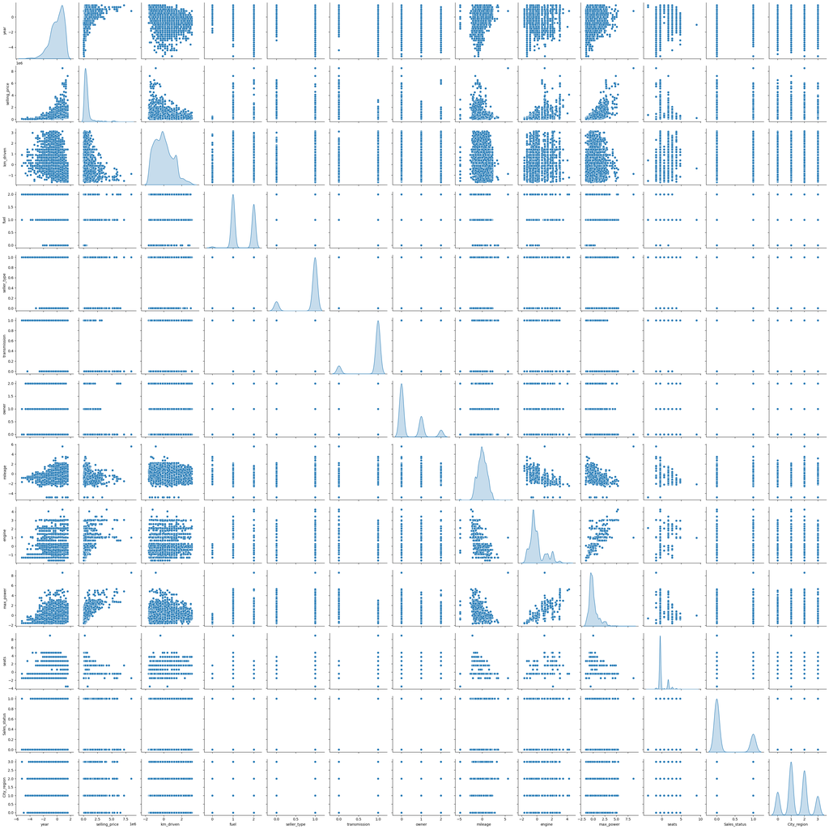

```python
#Linearity
sns.pairplot(cleaned_car_sales,diag_kind="kde")
```

##### Check the multicollinearity using VIF for all the variables in the model

#### NOTE:

- Splits the data into training and testing sets using the train_test_split function from scikit-learn.
- Define the dependent variable (y1) and independent variables (X1) using the `dmatrices` function from the `patsy` module.
- For each independent variable in X1, it calculates the VIF using the variance_inflation_factor function from the statsmodels.stats.outliers_influence module. VIF measures how much the variance of an estimated regression coefficient increases if your predictors are correlated.
- Store the calculated VIF values along with the corresponding feature names in a DataFrame `vif` to display the VIF values for each feature.

```python
from statsmodels.stats.outliers_influence import variance_inflation_factor
from patsy import dmatrices
#import statsmodels.stats.outliers_influence as oi
import statsmodels.api as sm

def multicollinearity(data):
    y = data['selling_price']
    X = data.drop('selling_price',axis = 1)
    X_train, X_test, y_train , y_test = train_test_split(X,y,test_size = 0.2,random_state = 1234 )

    # For each X, calculate VIF and save in dataframe
#     formula = 'y ~ ' + '+'.join(X_train.columns)
#     y_train_dmatrix, X_train_dmatrix = (formula, data = X_train,return_type='dataframe')
#     y_test_dmatrix, X_test_dmatrix = (formula, data = X_test,return_type='dataframe')
#     vif = pd.DataFrame()
#     vif['feature'] = X_train.columns
#     vif['VIF'] = [variance_inflation_factor(X_train_dmatrix.values,i) for i in range(len(X_train.columns))]


    vif = pd.DataFrame()
    for feature in X_train.columns:
#       y_train_dmatrix, X_train_dmatrix = dmatrices(formula = 'y ~ ' + feature, data = X_train, return_type = 'dataframe')
#        X_train_dmatrix = pd.concat([pd.Series(1, index = X_train.index), X_train[[feature]]],axis=1)
#        vif.loc[feature,'VIF'] = (oi.influence_matrix(X_train_dmatrix.values)).mean()
        model = sm.OLS(y_train, sm.add_constant(X_train[[feature]]))
        results = model.fit()
        vif.loc[feature,'VIF'] = 1/ (1-results.resid**2).sum()

    return vif
```

```python
multicollinearity(cleaned_car_sales)
```

|  | VIF |
| --- | --- |
| year | -2.879526e-16 |
| km_driven | -2.605077e-16 |
| fuel | -2.474431e-16 |
| seller_type | -2.840491e-16 |
| transmission | -3.669031e-16 |
| owner | -2.523122e-16 |
| mileage | -2.422103e-16 |
| engine | -2.980137e-16 |
| max_power | -5.424186e-16 |
| seats | -2.389838e-16 |
| Sales_status | -2.387356e-16 |
| City_region | -2.386184e-16 |

#### T2.4: Build a multiple linear regression model on training data using OLS method and sklearn library . (weightage - 15 marks) (AE)

#### NOTE:

- Split the dataset into train and test in the ratio of 80:20.
- Set the random_state to 1234
- Build the OLS model using statsmodels formula API
- The function `fit_the_model_ols` should return the OLS Model and the test data.

**Build a model using OLS**

```python
import statsmodels.formula.api as smf
#import statsmodels.api as sm
def fit_the_model_ols(data):
    ols_model = None
#    features= None
    train, test = np.ndarray([]),np.ndarray([])
    # Code starts here
#     if features is None:
#         features = [col for col in data.columns if col != 'selling_price']
#     formula = f'selling_price ~ {" + ".join(features)}'
    train, test = train_test_split(data,test_size = 0.2,random_state = 1234)
#     X = data.drop('selling_price',axis=1)
#     y = data['selling_price']
#     X_train, X_test, y_train , y_test = train_test_split(X,y,test_size = 0.2,random_state = 1234 )
#     formula = 'selling_price ~ ' + ' + '.join(X.columns)

    # Building the OLS model using statsmodels formula API
    #ols_model = sm.OLS(y_train,sm.formula.formula(formula,data = X_train)).fit()
    ols_model = smf.ols(formula='selling_price ~'+ ' + '.join(data.columns.difference(['selling_price'])), data =train).fit()
#   test = pd.concat([X_test,y_test],axis=1)
    # Return the model and the test data
    return ols_model,test
```

```python
# Fit the model
ols_model, test_data = fit_the_model_ols(cleaned_car_sales)
```

```python
# Get the summary of the fitted model
summary = ols_model.summary()
# Print the summar
summary
```

OLS Regression Results

| Dep. Variable: | selling_price | R-squared: | 0.685 |
| --- | --- | --- | --- |
| Model: | OLS | Adj. R-squared: | 0.684 |
| Method: | Least Squares | F-statistic: | 1143. |
| Date: | Wed, 26 Jun 2024 | Prob (F-statistic): | 0.00 |
| Time: | 14:35:02 | Log-Likelihood: | -91390. |
| No. Observations: | 6324 | AIC: | 1.828e+05 |
| Df Residuals: | 6311 | BIC: | 1.829e+05 |
| Df Model: | 12 |  |  |
| Covariance Type: | nonrobust |  |  |

|  | coef | std err | t | P>\|t\| | [0.025 | 0.975] |
| --- | --- | --- | --- | --- | --- | --- |
| Intercept | 1.395e+06 | 3.42e+04 | 40.783 | 0.000 | 1.33e+06 | 1.46e+06 |
| City_region | -2515.0390 | 6264.619 | -0.401 | 0.688 | -1.48e+04 | 9765.745 |
| Sales_status | 2.103e+04 | 1.32e+04 | 1.594 | 0.111 | -4841.116 | 4.69e+04 |
| engine | 2.457e+04 | 1.3e+04 | 1.895 | 0.058 | -849.844 | 5e+04 |
| fuel | -1.167e+05 | 1.56e+04 | -7.494 | 0.000 | -1.47e+05 | -8.62e+04 |
| km_driven | -1.092e+05 | 7429.689 | -14.697 | 0.000 | -1.24e+05 | -9.46e+04 |
| max_power | 4.614e+05 | 1.02e+04 | 45.430 | 0.000 | 4.41e+05 | 4.81e+05 |
| mileage | 4.239e+04 | 9430.742 | 4.495 | 0.000 | 2.39e+04 | 6.09e+04 |
| owner | -1677.8845 | 1.04e+04 | -0.161 | 0.872 | -2.22e+04 | 1.88e+04 |
| seats | -2.936e+04 | 8444.806 | -3.476 | 0.001 | -4.59e+04 | -1.28e+04 |
| seller_type | -2.238e+05 | 1.8e+04 | -12.442 | 0.000 | -2.59e+05 | -1.89e+05 |
| transmission | -4.445e+05 | 2.2e+04 | -20.181 | 0.000 | -4.88e+05 | -4.01e+05 |
| year | 1.056e+05 | 8427.249 | 12.531 | 0.000 | 8.91e+04 | 1.22e+05 |

| Omnibus: | 3345.822 | Durbin-Watson: | 1.981 |
| --- | --- | --- | --- |
| Prob(Omnibus): | 0.000 | Jarque-Bera (JB): | 51894.938 |
| Skew: | 2.174 | Prob(JB): | 0.00 |
| Kurtosis: | 16.343 | Cond. No. | 18.2 |

Notes:  
[1] Standard Errors assume that the covariance matrix of the errors is correctly specified.

**Build a linear model using sklearn library**

#### NOTE:

- Initializes a linear regression model object.
- Fit the model to the training data (X_train and y_train) using the fit() method of the linear regression object.

```python
from sklearn.linear_model import LinearRegression
def fit_the_model_on_the_training_data(data,X_train:np.ndarray,y_train:np.ndarray):
    regression = None
    # Code starts here
    reg = LinearRegression()

    regression= reg.fit(X_train, y_train)

    # Code ends here
    return regression
```

```python
# train the training data
sklearn_model=fit_the_model_on_the_training_data(cleaned_car_sales,X_train,y_train)
```

#### T2.5 Model Versioning: (weightage -3 marks) (ME)

Save the initial version of a linear regression model OLS codebase named 'first_model' to a version control system GitHub using git commands for facilitating collaboration, tracking changes, and ensuring transparency in model development.

Save the version of a linear regression model (sklearn) codebase named 'second_model' to a version control system GitHub using git commandsin git bash, if required facilitating collaboration, tracking changes, and ensuring transparency in model development.

#### Model Versioning:

Save the above version of a linear regression model (sklearn) codebase named 'second_model' to a version control system GitHub using git commandsin git bash, if required facilitating collaboration, tracking changes, and ensuring transparency in model development.

### Task 3: Evaluate the performance of the model using the right evaluation metrics. (weightage - 35 marks)

#### T3.1: Bring the initial version of a linear regression model 'first_model' and second version ‘second_model’ from a GitHub using git commands and evaluate the model (weightage - 2 marks) (ME)

#### Model Versioning:

Bring the initial version of a linear regression model 'first_model' from a GitHub using git commands and evaluate the model.

```python
import pickle
with open("first_model.pkl","wb") as model_file:
    pickle.dump(ols_model,model_file)
```

Bring the second version of a linear regression model sklearn 'second_model' from GitHub using git commands, and evaluate the model.

```python
with open("second_model.pkl","wb") as model_file:
    pickle.dump(sklearn_model,model_file)
```

#### T3.2: Evaluate the linear regression model with evaluation metrics R2 and RMSE using OLS and sklearn library. (weightage - 4 marks) (AE)

**Evaluate the OLS model**

#### NOTE

- Make the predictions on the test set using the provided OLS linear regression model
- Calculate the RMSE by comparing the predicted selling prices with the actual selling prices in the test set, using the mean_squared_error function from scikit-learn.
- Calculate the R-squared (R²) value using the rsquared attribute of the linear regression model.
- Return both `RMSE` and `R²` value.

```python
from sklearn.metrics import mean_squared_error
def ols_calculate_rmse_r2(model, test_data):
    rmse,r_squared = 0.0,0.0
    # Making predictions on the test set
    y_pred = model.predict(test_data)

    # Calculating RMSE
    rmse = np.sqrt(mean_squared_error(test_data['selling_price'],y_pred))
    r_squared = model.rsquared
    return rmse,r_squared
```

```python
ols_rmse, ols_r_squared = ols_calculate_rmse_r2(ols_model, test_data)
```

```python
# OLS Model RMSE value
print (ols_rmse)
```

```
446620.5918339133
```

```python
# OLS R2 value
print (ols_r_squared)
```

```
0.6849441555571829
```

**Evaluate the Sklearn model**

#### NOTE:

- Make the predictions using a trained scikit-learn model (model) on a test dataset (X_test)
- Using the trained model predict the target variable for the provided test dataset (X_test) using the predict() method of the model.
- Return the predicted target variable values

```python
def test_the_sklearn_model(model, X_test: np.ndarray) -> np.ndarray:
    y_prediction = np.ndarray([])
    # code starts here
    y_prediction = model.predict(X_test)

    # code ends here
    return y_prediction
```

```python
y_pred=test_the_sklearn_model(sklearn_model,X_test)
y_pred
```

```
array([646089.04425748, 222730.119761  , 152196.97832912, ...,
       201517.25533107, 746239.99563138, 133888.96669395])
```

**Evaluate the model with evaluation metric R2 and RMSE**

```python
from sklearn.metrics import r2_score, mean_squared_error
def calculate_r_squared_sklearn(y_true, y_pred):
    """
    Calculate the R-squared (coefficient of determination) metric using scikit-learn.

    Parameters:
    y_true : numpy.ndarray
        True target values.
    y_pred : numpy.ndarray
        Predicted target values.

    Returns:
    float
        R-squared value.
    """
    r_squared = None
    # Code starts here
    mean_true = np.mean(y_true)
    n = np.sum((y_true - mean_true) **2)
    d = np.sum((y_true - y_pred) **2)
    # rmse = np.sqrt(mean_squared_error(y_test,y_pred))
    r_squared = 1 - (d/n)

    # Code ends here
    return r_squared
```

```python
def calculate_rmse_sklearn(y_true, y_pred):
    """
    Calculate the Root Mean Squared Error (RMSE) metric using scikit-learn.

    Parameters:
    y_true : numpy.ndarray
        True target values.
    y_pred : numpy.ndarray
        Predicted target values.

    Returns:
    float
        RMSE value.
    """
    rmse = None
    # Code starts here
    rmse = np.sqrt(mean_squared_error(y_test,y_pred))
    # r_squared = model.score(X_test,y_test)

    # Code ends here
    return rmse
```

```python
# Calculate R-squared
r_squared = calculate_r_squared_sklearn(y_test, y_pred)
print(r_squared)
```

```
0.6893185564242086
```

```python
# Calculate RMSE
rmse = calculate_rmse_sklearn(y_test, y_pred)
print(rmse)
```

```
446620.5918339134
```

#### T3.3:Remove the insignificant variables which identified by OLS and multicollinearity -VIF technique. Then apply log transformation on target variable and build the model using sklearn library. Save the version of this linear regression model named 'final_model' to a Github, and evaluate it with R2 and RMSE(weightage - 5 marks) (AE)

**Remove insignificant variable**

#### NOTE:

```python
def drop_variables(data):
    features_to_drop = ['engine','City_region','owner','Sales_status']
    for feature in features_to_drop:
        data.drop(feature,axis=1)

    return data
```

```python
cleaned_car_sales=drop_variables(cleaned_car_sales)
```

**Apply Log transformation on target variable**

#### NOTE:

- Transform the target variable 'selling_price' into its natural logarithm ('ln_selling_price') using the numpy log function
- Return the ln_selling_price' column, which contains the transformed target variable values.

```python
def target_transform(data):
    data['ln_selling_price'] = np.log(data['selling_price'])

    return data["ln_selling_price"]
```

```python
target_transform(cleaned_car_sales)
```

```
0       13.017003
1       12.821258
2       11.970350
3       12.323856
4       11.775290
          ...
7901    12.676076
7902    11.813030
7903    12.853176
7904    12.577636
7905    12.577636
Name: ln_selling_price, Length: 7906, dtype: float64
```

**Separate independent features and target variable**

#### NOTE:

- Extract the feature variables (X) by dropping the columns 'ln_selling_price' and 'selling_price' from the DataFrame df using the drop() method
- Extract the target variable (y) by selecting only the 'ln_selling_price' column from the DataFrame df.

```python
def separate_data_and_target_new(df):
    X,y = np.ndarray([]),np.ndarray([])
    # Code starts here
    X = df.drop(columns=['ln_selling_price','selling_price'])
    y = df['ln_selling_price']
    # Code ends here
    return X,y
```

```python
X, y = separate_data_and_target_new(cleaned_car_sales)
```

```python
# split into training and testing
X_train, X_test,y_train,y_test=split_into_train_and_test_normalize_features(X,y)
```

```python
final_model=fit_the_model_on_the_training_data(cleaned_car_sales,X_train,y_train)
```

#### Model Versioning:

Save the above version of a linear regression model (sklearn) codebase named 'final_model' to a version control system GitHub using git commandsin git bash, if required facilitating collaboration, tracking changes, and ensuring transparency in model development.

```python
with open("final_model.pkl",'wb') as f:
    pickle.dump(final_model,f)
```

#### Model Versioning:

Bring the above version of a linear regression model skelarn 'final_model' from GitHub using git commands, and evaluate the model.

```python
#Test the model on the testing dataset and return the predicted values for the test dataset
def test_the_finalmodel(model1, X_test):
    y_prediction = np.ndarray([])
    # code starts here
    y_prediction = model1.predict(X_test)
    # code ends here
    return y_prediction
```

```python
#prediction
y_pred_1=test_the_finalmodel(final_model, X_test)
```

```python
def calculate_r_squared_finalmodel(y_true, y_pred):
    """
    Calculate the R-squared (coefficient of determination) metric using scikit-learn.

    Parameters:
    y_true : numpy.ndarray
        True target values.
    y_pred : numpy.ndarray
        Predicted target values.

    Returns:
    float
        R-squared value.
    """
    r_squared = None
    # Code starts here
    mean_true = np.mean(y_true)
    n = np.sum((y_true - mean_true) **2)
    d = np.sum((y_true - y_pred) **2)
    # rmse = np.sqrt(mean_squared_error(y_test,y_pred))
    r_squared = 1 - (d/n)

    # Code ends here
    return r_squared
```

```python
def calculate_rmse_finalmodel(y_true, y_pred):
    """
    Calculate the Root Mean Squared Error (RMSE) metric using scikit-learn.

    Parameters:
    y_true : numpy.ndarray
        True target values.
    y_pred : numpy.ndarray
        Predicted target values.

    Returns:
    float
        RMSE value.
    """
    rmse = None
    # Code starts here

    rmse = np.sqrt(mean_squared_error(y_true,y_pred))
    # Code ends here

    return rmse
```

```python
#r-squared
r_squared_final_model = calculate_r_squared_finalmodel(y_test, y_pred_1)
print(r_squared_final_model)
```

```
0.8784496357480035
```

```python
#rmse
rmse_final_model = calculate_rmse_finalmodel(y_test, y_pred_1)
print(rmse_final_model)
```

```
0.2889137443665591
```

```python
# Get the coefficient for the 'km_driven' feature
def coefficient_km():
    km_driven_coefficient = None
    # Code starts here'
    #feature_name = getattr(final_model,'feature_names_in_')
#     if hasattr(final_model,'coef_'):
#         feature_names = final_model.feature_names_in
#     try:
#         feature_index = feature_names.index('km_driven')
#         km_driven_coefficient = final_coef_[feature_index]
        #m_driven_coefficient = pd.DataFrame(final_model.coef_,index=X.columns.values)
    #[feature_name.index('km_driven')]
    km_driven_coefficient = final_model.coef_[1]
    # Code ends here
    return km_driven_coefficient
```

```python
coefficient_km()
```

```
-0.0727205316687044
```

#### T3.5: Ensure residues are random i.e. normally distributed using histplot / QQ plot (weightage - 2 marks) (ME)

#### NOTE:

- Create a histogram plot of the residuals (the differences between the actual and predicted values of the target variable) using Seaborn's histplot function.

```python
def residual_plot(y_test, y_pred):
    residual = y_test - y_pred
    sns.histplot(residual,kde=True,stat="density")
    plt.xlabel("Residual")
    plt.ylabel("Density")
    plt.title("Histogram of Residuals")
    plt.legend()
    plt.show()

    return
```

```
No artists with labels found to put in legend.  Note that artists whose label start with an underscore are ignored when legend() is called with no argument.
```

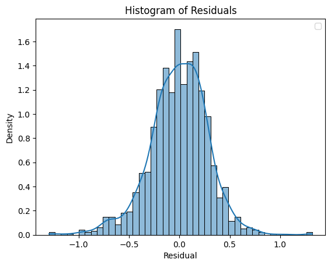

```python
residual_plot(y_test, y_pred_1)
```

#### NOTE:

- Generate a Q-Q plot to visually assess the normality of residuals.

```python
# Add Q-Q plot for residual normality

def QQ_plot(y_test, y_pred):
    residual = y_test - y_pred
    sm.qqplot(residual)
    plt.xlabel("Quantiles Theoritical Normal")
    plt.ylabel("Quantiles Residuals")
    plt.title("QQ Plot of Residuals")
    plt.show()

    return
```

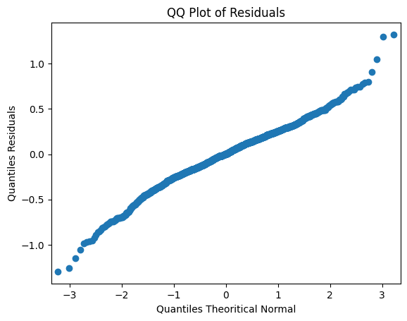

```python
QQ_plot(y_test,y_pred_1)
```

```python
# import shap
# sample = shap.utils.sample(X=X, nsamples=200)

# # Partial dependence plot for body-mass index variable
# shap.partial_dependence_plot(

#    ind='km_driven',
#    model=final_model.predict,
#    data=sample,
#    ice=False,
#    model_expected_value=True,
#    feature_expected_value=True
# )
```

#### T3.7:Implement the unit test case and deploy a model using Flask / Streamlit. (weightage - 15 marks) (ME)

```python
# import unittest
# from sklearn.datasets import make_regression

# def get_mock_data():
#     X,y = make_regression(n_samples=100,n_features=5,noise=0.1)
#     df = pd.DataFrame(X,columns=[f'feature_{i}' for i in range(X.shape[1])])
#     df['selling_price'] = y
#     return df

# def load_model(file_path):
#     with open(file_path,'rb') as file:
#         model = pickle.load(file)
#     return model

# class TestModel(unittest.TestCase):

#     @classmethod
#     def setUpClass(cls):
#         data = get_mock_data()
#         final_model = load_model('final_model.pkl')
#         cls.model = final_model(data)
#     def test_model_performance(self):
#         rmse =  calculate_rmse_finalmodel(y_test, y_pred_1)
#         r_squared =  calculate_r_squared_finalmodel(y_test, y_pred_1)
#         self.assertLess(rmse,10)
#         self.assertGreater(r_squared,0.7)

# def run_tests():
#     suite = unittest.TestLoader().loadTestsFromTestCase(TestModel)
#     unittest.TextTestRunner().run(suite)

# # if __name__ == '__main__':
# #     unittest.main()

# run_tests()
```

```python
# from flask import Flask,request,jsonify

# app = Flask(__name__)

# @app.route('/predict',methods=['POST'])

# def predict():
#     data = request.get_json(force=True)
#     df = pd.DataFrame(data)
#     predictions = final_model.predict(df)
#     return jsonify(predictions.tolist())

# if __name__ == '__main__':
#     from werkzeug.serving import run_simple
#     run_simple('localhost',5000,app)
```

```python
# import requests
# import json

# url = 'http://localhost:5000/predict'
# test_data = get_mock_data().drop(columns = 'selling_price').iloc[:5].to_dict(orient='records')
# response = requests.post(url,json=test_data)
# print(response.json())
```

### Task 4: Summarize the findings of the analysis and draw conclusions with PPT / PDF. (weightage - 15 marks) (ME)

## Comparing linear regression with other models

### Final Submission guidelines:

- Download the Jupyter notebook in the format of html.
- Upload it in the lumen (UNext LMS)
- Take a screenshot of T3.7 (Deployment) and upload it in the lumen (UNext LMS)
- Summarized PPT/ PDF prepared in Task 4 to be uploaded in the lumen (UNext LMS)

-------------------------------------------------- **ASSESSMENT ENDS HERE** ---------------------------------------------------------